# Time

2023-03-13

#### **Introduction**

This module of the *bdc* package extracts the collection year whenever possible from complete and legitimate date information and flags dubious (e.g., 07/07/10), illegitimate (e.g., 1300, 2100), or not supplied (e.g., 0 or NA) collecting year.

#### **Installation**

Check [**here**](https://brunobrr.github.io/bdc/#installation) how to install the bdc package.

#### **Reading the database**

Read the database created in the [**Space**](https://brunobrr.github.io/bdc/articles/space.html) module of the *bdc* package. It is also possible to read any datasets containing the **required** fields to run the function (more details [here](https://brunobrr.github.io/bdc/articles/integrate_datasets.html)).

```r
database <-
  readr::read_csv(here::here("Output/Intermediate/03_space_database.csv"))
```

| database_id | verbatim_scientificName | decimalLatitude | decimalLongitude | occurrenceID | verbatimEventDate | country | stateProvince | county | locality | coordinatePrecision | basisOfRecord | identifiedBy | coordinateUncertaintyInMeters | recordedBy | country_suggested | countryCode | .uncer_terms | original_search | suggested_name | distance | notes | taxonID | scientificName | taxonRank | taxonomicStatus | acceptedNameUsageID | kingdom | phylum | class | … |
| --- | --- | --- | --- | --- | --- | --- | --- | --- | --- | --- | --- | --- | --- | --- | --- | --- | --- | --- | --- | --- | --- | --- | --- | --- | --- | --- | --- | --- | --- | --- |
| AT_EPIPHYTES_1 | Tillandsia tenuifolia | -25.521863 | -51.416667 | E8802 | 2003 | Brazil | PARANA | GUARAPUAVA | Rio Sao Jeronimo | Forest fragment |  |  |  |  | Brazil | BR | True | Tillandsia tenuifolia |  |  | accepted | GBIF:2695114 | Tillandsia tenuifolia | species | accepted | GBIF:2695114 | Plantae | Tracheophyta | Liliopsida | … |
| AT_EPIPHYTES_2 | Peperomia obtusifolia | -14.65972 | -39.14972 | 635992 | 2015 | Brazil | BAHIA | ILHEUS |  | Coordinates given in the herbarium record |  |  |  |  | Brazil | BR | True | Peperomia obtusifolia |  |  | accepted | GBIF:3086423 | Peperomia obtusifolia | species | accepted | GBIF:3086423 | Plantae | Tracheophyta | Magnoliopsida | … |
| AT_EPIPHYTES_3 | Tillandsia recurvata | -21.746667 | -43.354722 | E1617 | 2016 | Brazil | MATO GROSSO DO SUL | JUIZ DE FORA | Praca Mariano Procopio | 50 |  |  |  |  | Brazil | BR | True | Tillandsia recurvata |  |  | accepted | GBIF:2695588 | Tillandsia recurvata | species | accepted | GBIF:2695588 | Plantae | Tracheophyta | Liliopsida | … |
| AT_EPIPHYTES_4 | Vriesea flammea | -23.35 | -44.858333 | E0272 | 2011 | Brazil | SAO PAULO | UBATUBA | Parque Estadual da Serra do Mar-Nucleo Picinguaba | Forest fragment |  |  |  |  | Brazil | BR | True | Vriesea flammea |  |  | accepted | GBIF:5289378 | Vriesea flammea | species | accepted | GBIF:5289378 | Plantae | Tracheophyta | Liliopsida | … |
| AT_EPIPHYTES_5 | Lankesterella ceracifolia | -28.1667 | -49.4 | 17541 | 2009 | Brazil | SANTA CATARINA | ORLEANS | Rio Minador | Municipality |  |  |  |  | Brazil | BR | True | Lankesterella ceracifolia |  |  | accepted | GBIF:5312267 | Lankesterella ceracifolia | species | accepted | GBIF:5312267 | Plantae | Tracheophyta | Liliopsida | … |
| AT_EPIPHYTES_7 | Nidularium innocentii | -26.1833 | -49.0333 | 20521 | 2009 | Brazil | SANTA CATARINA | JOINVILLE | Serra Dona Francisca | Municipality |  |  |  |  | Brazil | BR | True | Nidularium innocentii |  |  | accepted | GBIF:2697762 | Nidularium innocentii | species | accepted | GBIF:2697762 | Plantae | Tracheophyta | Liliopsida | … |
| AT_EPIPHYTES_8 | Acianthera serpentula | -25.5839 | -49.6356 | E23503 |  | Brazil | PARANA | BALSA NOVA | Base da Serra de Sao Luiz do Puruna | Coordinates given in the herbarium record |  |  |  |  | Brazil | BR | True | Acianthera serpentula |  |  | accepted | GBIF:2839474 | Acianthera serpentula | species | accepted | GBIF:2839474 | Plantae | Tracheophyta | Liliopsida | … |
| AT_EPIPHYTES_9 | Peperomia quadrifolia | -26.46 | -49.41 | E18657 |  | Brazil | SANTA CATARINA | CORUPA | Palmeiras II | Coordinates given in the herbarium record |  |  |  |  | Brazil | BR | True | Peperomia quadrifolia |  |  | accepted | GBIF:3086416 | Peperomia quadrifolia | species | accepted | GBIF:3086416 | Plantae | Tracheophyta | Magnoliopsida | … |
| AT_EPIPHYTES_10 | Peperomia circinnata | -23.7869 | -54.2836 | E16998 |  | Brazil | MATO GROSSO DO SUL | ELDORADO |  | Coordinates given in the herbarium record |  |  |  |  | Brazil | BR | True | Peperomia circinnata |  |  | accepted | GBIF:7304921 | Peperomia circinnata | species | accepted | GBIF:7304921 | Plantae | Tracheophyta | Magnoliopsida | … |
| AT_EPIPHYTES_11 | Microgramma squamulosa | -25.666271 | -49.269229 | E7552 | 2017 | Brazil | PARANA | FAZENDA RIO GRANDE | Fazenda Experimental Gralha Azul 2 | Forest fragment |  |  |  |  | Brazil | BR | True | Microgramma squamulosa |  |  | accepted | GBIF:4025976 | Microgramma squamulosa | species | accepted | GBIF:4025976 | Plantae | Tracheophyta | Polypodiopsida | … |

[output cut: 5 more lines]

⚠️**IMPORTANT:**

The results of the VALIDATION test used to flag data quality are appended in separate fields in this database and retrieved as TRUE (✅ ok) or FALSE (❌check carefully).

#### **1 - Records lacking event date information**

*VALIDATION*. This function flags records lacking event date information (e.g., empty or NA).

```r
check_time <-
  bdc_eventDate_empty(data = database, eventDate = "verbatimEventDate")
```

```
#>
#> bdc_eventDate_empty:
#> Flagged 64 records.
#> One column was added to the database.
```

#### **2 - Extract year from event date**

*ENRICHMENT*. This function extracts four-digit years from unambiguously interpretable collecting dates.

```r
check_time <-
  bdc_year_from_eventDate(data = check_time, eventDate = "verbatimEventDate")
```

```
#>
#> bdc_year_from_eventDate:
#> Four-digit year were extracted from 51 records.
```

#### **3 - Records with out-of-range collecting year**

*VALIDATION*. This function identifies records with illegitimate or potentially imprecise collecting years. The year provided can be out-of-range (e.g., in the future) or collected before a specified year supplied by the user (e.g., 1900). Older records are more likely to be imprecise due to the locality-derived geo-referencing process.

```r
check_time <-
  bdc_year_outOfRange(data = check_time,
                      eventDate = "year",
                      year_threshold = 1900)
```

```
#>
#> bdc_year_outOfRange:
#> Flagged 0 records.
#> One column was added to the database.
```

#### **Report**

Here we create a column named **.summary** summing up the results of all **VALIDATION** tests. This column is **FALSE** when a record is flagged as FALSE in any data quality test (❌check carefully. potentially invalid or suspect record).

```r
check_time <- bdc_summary_col(data = check_time)
```

```
#> Column '.summary' already exist. It will be updated
#>
#> bdc_summary_col:
#> Flagged 70 records.
#> One column was added to the database.
```

Creating a report summarizing the results of all tests of the *bdc* package. The report can be automatically saved if `save_report = TRUE.`

```r
report <-
  bdc_create_report(data = check_time,
                    database_id = "database_id",
                    workflow_step = "time",
                    save_report = FALSE)

report
```

[output not shown]

#### **Figures**

Here we create figures (bar plots and histrogram) to make the interpretation of the results of data quality tests easier. See some examples below. Figures can be automatically saved if `save_figures = TRUE.`

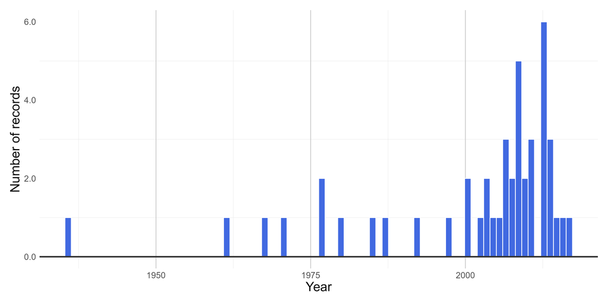

Number of records sampled over the years

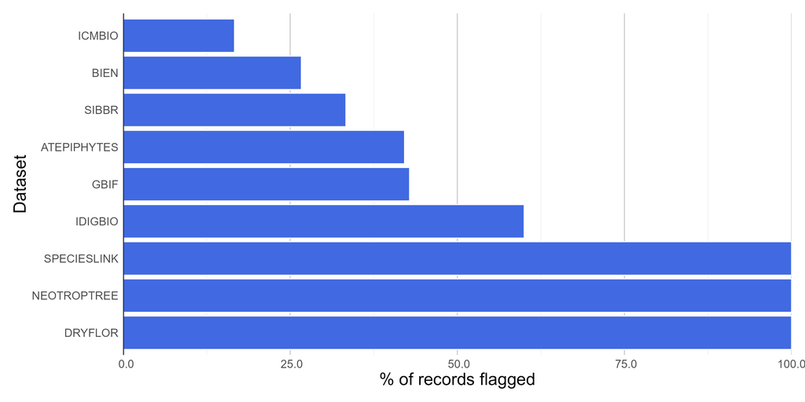

Summary of all tests of the time module; note that some database lack event date information

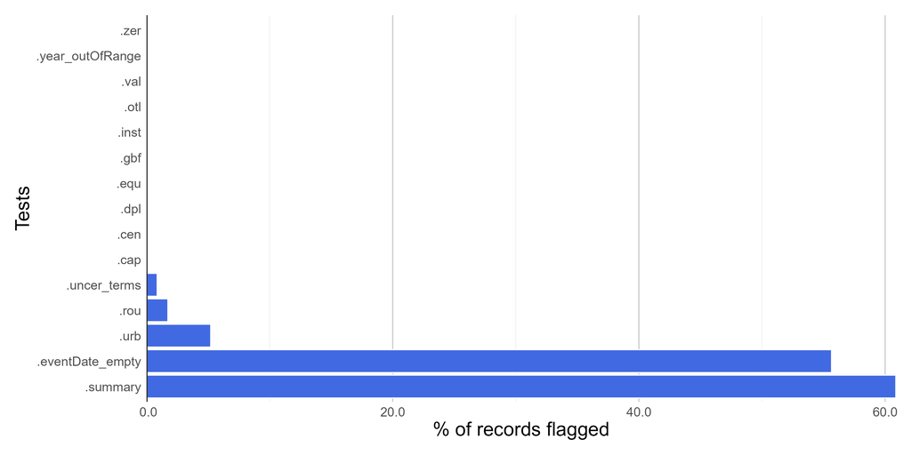

Summary of all validation tests of the bdc package

```r
figures <-
bdc_create_figures(data = check_time,
                   database_id = "database_id",
                   workflow_step = "time",
                   save_figures = FALSE)

# Check figures using
figures$time_year_BAR
```

#### **Saving a “raw” database**

```r
check_time %>%
  readr::write_csv(.,
            here::here("Output", "Intermediate", "04_time_database.csv"))
```

#### **Filtering the database**

```r
output <-
  check_time %>%
  dplyr::filter(.summary == TRUE) %>%
  bdc_filter_out_flags(data = ., col_to_remove = "all")
```

```
#>
#> bdc_fiter_out_flags:
#> The following columns were removed from the database:
#> .uncer_terms, .rou, .val, .equ, .zer, .cap, .cen, .urb, .otl, .gbf, .inst, .dpl, .eventDate_empty, .year_outOfRange, .summary
```

#### **Saving a clean “fitness-for-use” database**

You can use qs::qsave() instead of write_csv to save a large database in a compressed format.

```r
# use qs::qsave() to save the database in a compressed format and then qs:qread() to load the database
output %>%
  readr::write_csv(.,
            here::here("Output", "Intermediate", "05_cleaned_database.csv"))
```

| database_id | verbatim_scientificName | decimalLatitude | decimalLongitude | occurrenceID | verbatimEventDate | country | stateProvince | county | locality | coordinatePrecision | basisOfRecord | identifiedBy | coordinateUncertaintyInMeters | recordedBy | country_suggested | countryCode | original_search | suggested_name | distance | notes | taxonID | scientificName | taxonRank | taxonomicStatus | acceptedNameUsageID | kingdom | phylum | class | order | … |
| --- | --- | --- | --- | --- | --- | --- | --- | --- | --- | --- | --- | --- | --- | --- | --- | --- | --- | --- | --- | --- | --- | --- | --- | --- | --- | --- | --- | --- | --- | --- |
| AT_EPIPHYTES_1 | Tillandsia tenuifolia | -25.521863 | -51.416667 | E8802 | 2003 | Brazil | PARANA | GUARAPUAVA | Rio Sao Jeronimo | Forest fragment |  |  |  |  | Brazil | BR | Tillandsia tenuifolia |  |  | accepted | GBIF:2695114 | Tillandsia tenuifolia | species | accepted | GBIF:2695114 | Plantae | Tracheophyta | Liliopsida | Poales | … |
| AT_EPIPHYTES_2 | Peperomia obtusifolia | -14.65972 | -39.14972 | 635992 | 2015 | Brazil | BAHIA | ILHEUS |  | Coordinates given in the herbarium record |  |  |  |  | Brazil | BR | Peperomia obtusifolia |  |  | accepted | GBIF:3086423 | Peperomia obtusifolia | species | accepted | GBIF:3086423 | Plantae | Tracheophyta | Magnoliopsida | Piperales | … |
| AT_EPIPHYTES_4 | Vriesea flammea | -23.35 | -44.858333 | E0272 | 2011 | Brazil | SAO PAULO | UBATUBA | Parque Estadual da Serra do Mar-Nucleo Picinguaba | Forest fragment |  |  |  |  | Brazil | BR | Vriesea flammea |  |  | accepted | GBIF:5289378 | Vriesea flammea | species | accepted | GBIF:5289378 | Plantae | Tracheophyta | Liliopsida | Poales | … |
| AT_EPIPHYTES_5 | Lankesterella ceracifolia | -28.1667 | -49.4 | 17541 | 2009 | Brazil | SANTA CATARINA | ORLEANS | Rio Minador | Municipality |  |  |  |  | Brazil | BR | Lankesterella ceracifolia |  |  | accepted | GBIF:5312267 | Lankesterella ceracifolia | species | accepted | GBIF:5312267 | Plantae | Tracheophyta | Liliopsida | Asparagales | … |
| AT_EPIPHYTES_7 | Nidularium innocentii | -26.1833 | -49.0333 | 20521 | 2009 | Brazil | SANTA CATARINA | JOINVILLE | Serra Dona Francisca | Municipality |  |  |  |  | Brazil | BR | Nidularium innocentii |  |  | accepted | GBIF:2697762 | Nidularium innocentii | species | accepted | GBIF:2697762 | Plantae | Tracheophyta | Liliopsida | Poales | … |
| AT_EPIPHYTES_11 | Microgramma squamulosa | -25.666271 | -49.269229 | E7552 | 2017 | Brazil | PARANA | FAZENDA RIO GRANDE | Fazenda Experimental Gralha Azul 2 | Forest fragment |  |  |  |  | Brazil | BR | Microgramma squamulosa |  |  | accepted | GBIF:4025976 | Microgramma squamulosa | species | accepted | GBIF:4025976 | Plantae | Tracheophyta | Polypodiopsida | Polypodiales | … |
| AT_EPIPHYTES_14 | Vriesea tijucana | -15.158634 | -39.057151 | 359 | 2000 | Brazil | BAHIA | UNA | Reserva Biologica de Una | 20 |  |  |  |  | Brazil | BR | Vriesea tijucana |  |  | accepted | GBIF:5288897 | Vriesea tijucana | species | accepted | GBIF:5288897 | Plantae | Tracheophyta | Liliopsida | Poales | … |
| AT_EPIPHYTES_16 | Anthurium gaudichaudianum | -29.342087 | -49.68663 | E0057 | 1992 | Brazil | RIO GRANDE DO SUL | TORRES | Torres | Forest fragment |  |  |  |  | Brazil | BR | Anthurium gaudichaudianum |  |  | accepted | GBIF:2872740 | Anthurium gaudichaudianum | species | accepted | GBIF:2872740 | Plantae | Tracheophyta | Liliopsida | Alismatales | … |
| AT_EPIPHYTES_18 | Acianthera langeana | -28.47165 | -49.981568 | E2724 | 2014 | Brazil | RIO GRANDE DO SUL | SAO JOSE DOS AUSENTES | Rio Pelotas | Forest fragment |  |  |  |  | Brazil | BR | Acianthera langeana |  |  | accepted | GBIF:2840033 | Acianthera langeana | species | accepted | GBIF:2840033 | Plantae | Tracheophyta | Liliopsida | Asparagales | … |
| AT_EPIPHYTES_19 | Pleopeltis monoides | -22.43083 | -42.74306 | 540781 | 2010 | Brazil | RIO DE JANEIRO | CACHOEIRAS DE MACACU |  | Coordinates given in the herbarium record |  |  |  |  | Brazil | BR | Pleopeltis monoides |  |  | accepted | GBIF:7495967 | Pleopeltis monoides | species | accepted | GBIF:7495967 | Plantae | Tracheophyta | Polypodiopsida | Polypodiales | … |

[output cut: 5 more lines]